# Assignment3

Julia Piscioniere

2/4/2019

```r
trees = read.csv('https://raw.githubusercontent.com/dmcglinn/quant_methods/gh-pages/data/treedata_subset.csv')

red_maples <- subset(trees, species == 'Acer rubrum')
frasier_fir <- subset(trees, species == 'Abies fraseri')
```

```r
red_maple_mod <- lm(cover ~ elev + tci + streamdist + disturb + beers, data = red_maples)

summary(red_maple_mod)
```

```
##
## Call:
## lm(formula = cover ~ elev + tci + streamdist + disturb + beers,
##     data = red_maples)
##
## Residuals:
##     Min      1Q  Median      3Q     Max
## -4.7073 -1.2446  0.3409  1.3575  5.2732
##
## Coefficients:
##                 Estimate Std. Error t value Pr(>|t|)
## (Intercept)    6.3502303  0.4564973  13.911  < 2e-16 ***
## elev          -0.0010108  0.0003161  -3.197  0.00145 **
## tci           -0.0627613  0.0351922  -1.783  0.07495 .
## streamdist     0.0012895  0.0004756   2.712  0.00686 **
## disturbLT-SEL  0.0829610  0.2166747   0.383  0.70192
## disturbSETTLE -0.1044556  0.2804213  -0.372  0.70963
## disturbVIRGIN  0.3088364  0.2518161   1.226  0.22044
## beers         -0.3269597  0.1089662  -3.001  0.00279 **
## ---
## Signif. codes:  0 '***' 0.001 '**' 0.01 '*' 0.05 '.' 0.1 ' ' 1
##
## Residual standard error: 1.989 on 715 degrees of freedom
## Multiple R-squared:  0.04493,    Adjusted R-squared:  0.03558
## F-statistic: 4.805 on 7 and 715 DF,  p-value: 2.669e-05
```

```r
anova(red_maple_mod)
```

```
## Analysis of Variance Table
##
## Response: cover
##             Df  Sum Sq Mean Sq F value   Pr(>F)
## elev         1   31.60  31.605  7.9900 0.004835 **
## tci          1   23.33  23.327  5.8972 0.015410 *
## streamdist   1   33.15  33.147  8.3800 0.003909 **
## disturb      3    9.35   3.117  0.7879 0.500831
## beers        1   35.61  35.613  9.0034 0.002789 **
## Residuals  715 2828.21   3.956
## ---
## Signif. codes:  0 '***' 0.001 '**' 0.01 '*' 0.05 '.' 0.1 ' ' 1
```

How well does the exploratory model appear to explain cover? The summary p-value is .00002669, indicating a meaningful relationship between the variables and cover. The low p-value is statistically significant. The other number to look at is the R-Squared. The R-squared in this case is .04493, saying that the model can explain 4.5% of the variability in cover. Which explanatory variables are the most important? The variables that are consistently important in both the summary and the anova test are elevation, stream distance, and beers, so these are the most important variables. TCI is more significant in the anova table with a significant p-value. Elevation and beers are both influencing cover negatively, so as they increase cover decreases. As stream distance increases, however, cover increases. When I changed this model and took out variables to either make it a purely negative model or positive model, the r2 decreases. Do model diagnostics reveal any problems with violations of OLS assumptions?

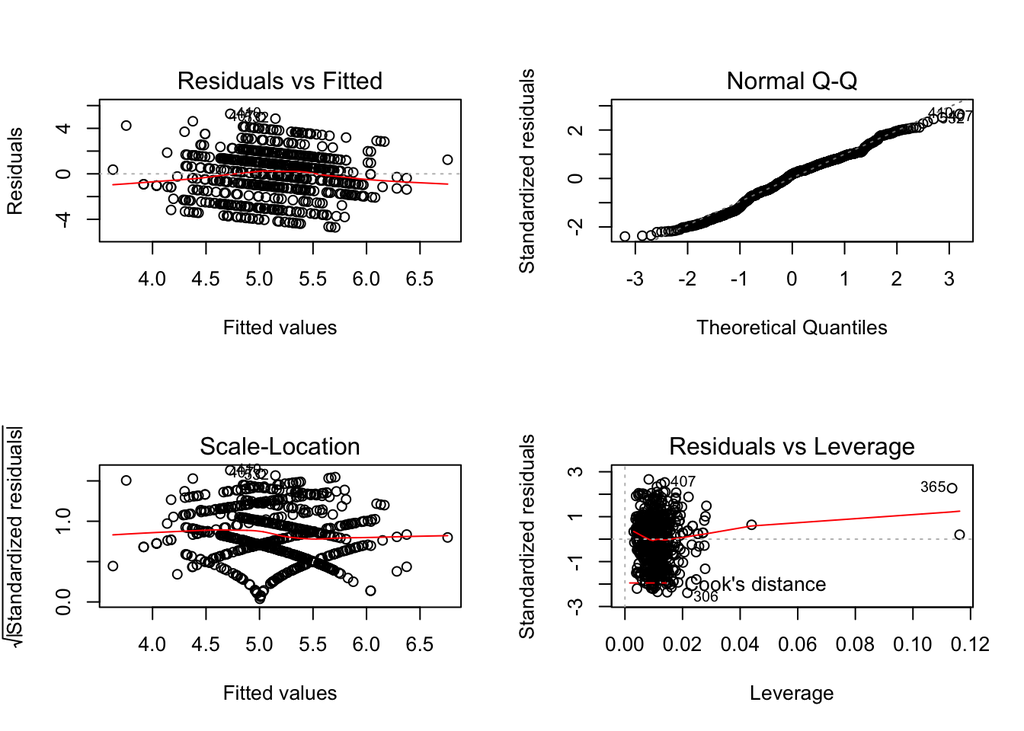

```r
par(mfrow = c(2,2))
plot(red_maple_mod)
```

The top right plot shows that the data is normally distributed because it mostly falls on the line, with slight deviation. The top left plot shows even distribution around the center line, so the assumption of homoscadisticity is held. The bottom left, also having to do with the error of the data is even around the center line with an interesting pattern in the lower half; this is not enough to say that the assumption is not held, however.

```r
frasier_fir_mod <- lm(cover ~ elev + tci + streamdist + disturb + beers, frasier_fir)

summary(frasier_fir_mod)
```

```
##
## Call:
## lm(formula = cover ~ elev + tci + streamdist + disturb + beers,
##     data = frasier_fir)
##
## Residuals:
##     Min      1Q  Median      3Q     Max
## -3.4630 -0.6472  0.0788  1.0872  3.8017
##
## Coefficients:
##                 Estimate Std. Error t value Pr(>|t|)
## (Intercept)   -20.561173   4.271449  -4.814 2.65e-05 ***
## elev            0.012370   0.002523   4.903 2.02e-05 ***
## tci             0.287641   0.193467   1.487   0.1458
## streamdist     -0.001266   0.001585  -0.799   0.4296
## disturbLT-SEL   2.188367   2.097905   1.043   0.3038
## disturbSETTLE   1.527604   2.341471   0.652   0.5183
## disturbVIRGIN   3.025596   1.735921   1.743   0.0899 .
## beers           0.037551   0.500269   0.075   0.9406
## ---
## Signif. codes:  0 '***' 0.001 '**' 0.01 '*' 0.05 '.' 0.1 ' ' 1
##
## Residual standard error: 1.601 on 36 degrees of freedom
## Multiple R-squared:  0.5824, Adjusted R-squared:  0.5011
## F-statistic: 7.171 on 7 and 36 DF,  p-value: 2.215e-05
```

```r
anova(frasier_fir_mod)
```

```
## Analysis of Variance Table
##
## Response: cover
##            Df  Sum Sq Mean Sq F value  Pr(>F)
## elev        1 105.749 105.749 41.2502 1.9e-07 ***
## tci         1   9.239   9.239  3.6038 0.06569 .
## streamdist  1   3.007   3.007  1.1729 0.28601
## disturb     3  10.679   3.560  1.3886 0.26196
## beers       1   0.014   0.014  0.0056 0.94058
## Residuals  36  92.289   2.564
## ---
## Signif. codes:  0 '***' 0.001 '**' 0.01 '*' 0.05 '.' 0.1 ' ' 1
```

How well does the exploratory model appear to explain cover? The summary p-value is .00002215, indicating a meaningful relationship between the variables and cover. The low p-value is statistically significant. The other number to look at is the R-Squared. The R-squared in this case is .5824, saying that the model can explain 58.24% of the variability in cover. This is a very good R-squared value, and a much better value than that of the red maple model; this is already showing that htis model better predicts cover for the frasier fir than the one is for the red maple. Which explanatory variables are the most important? The only variable that is consistently important in both the summary and the anova test is elevation, so this is the one most important value. Elevation here is positive, so as elevation increases the cover increases. This is different from the red maple model. Do model diagnostics reveal any problems with violations of OLS assumptions?

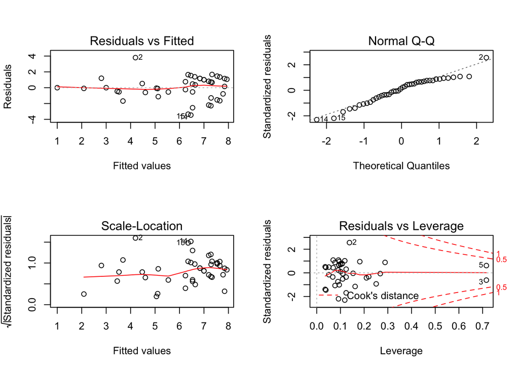

```r
par(mfrow = c(2,2))
plot(frasier_fir_mod)
```

These plots show that the data does not follow the assumptions. The top right plot shows that the data is not completely normally distributed because it deviates from the line and has outliers impacting the data. The two plots on the left show that the error is not the same across the line but it is concentrated in specific values.

Are you able to explain variance in one species better than another, why might this be the case? Yes, the variance is better explained in the frasier fir model because the r-squared is much higher than the red maple m model. Upon further analysis, it is most likely because the frasier fir data does not meet all of the OLS assumptions.

```r
frasier_fir_mod_decr <- lm(cover ~ elev, frasier_fir)

summary(frasier_fir_mod_decr)
```

```
##
## Call:
## lm(formula = cover ~ elev, data = frasier_fir)
##
## Residuals:
##    Min     1Q Median     3Q    Max
## -3.679 -1.488  0.488  1.214  3.418
##
## Coefficients:
##               Estimate Std. Error t value Pr(>|t|)
## (Intercept) -15.814670   3.526227  -4.485 5.56e-05 ***
## elev          0.011914   0.001919   6.208 1.99e-07 ***
## ---
## Signif. codes:  0 '***' 0.001 '**' 0.01 '*' 0.05 '.' 0.1 ' ' 1
##
## Residual standard error: 1.656 on 42 degrees of freedom
## Multiple R-squared:  0.4786, Adjusted R-squared:  0.4661
## F-statistic: 38.54 on 1 and 42 DF,  p-value: 1.991e-07
```

```r
anova(frasier_fir_mod_decr)
```

```
## Analysis of Variance Table
##
## Response: cover
##           Df Sum Sq Mean Sq F value    Pr(>F)
## elev       1 105.75 105.749  38.545 1.991e-07 ***
## Residuals 42 115.23   2.744
## ---
## Signif. codes:  0 '***' 0.001 '**' 0.01 '*' 0.05 '.' 0.1 ' ' 1
```

```r
red_maple_mod_glm <- glm(cover ~ elev + tci + streamdist + disturb + beers, data = red_maples, family = "poisson")

summary(red_maple_mod_glm)
```

```
##
## Call:
## glm(formula = cover ~ elev + tci + streamdist + disturb + beers,
##     family = "poisson", data = red_maples)
##
## Deviance Residuals:
##     Min       1Q   Median       3Q      Max
## -2.4282  -0.5903   0.1391   0.5786   2.1038
##
## Coefficients:
##                 Estimate Std. Error z value Pr(>|z|)
## (Intercept)    1.873e+00  1.023e-01  18.315  < 2e-16 ***
## elev          -1.961e-04  7.047e-05  -2.783  0.00538 **
## tci           -1.297e-02  8.159e-03  -1.589  0.11202
## streamdist     2.428e-04  1.030e-04   2.357  0.01843 *
## disturbLT-SEL  1.840e-02  4.880e-02   0.377  0.70619
## disturbSETTLE -1.739e-02  6.253e-02  -0.278  0.78099
## disturbVIRGIN  6.311e-02  5.638e-02   1.119  0.26293
## beers         -6.391e-02  2.423e-02  -2.638  0.00834 **
## ---
## Signif. codes:  0 '***' 0.001 '**' 0.01 '*' 0.05 '.' 0.1 ' ' 1
##
## (Dispersion parameter for poisson family taken to be 1)
##
##     Null deviance: 649.34  on 722  degrees of freedom
## Residual deviance: 623.38  on 715  degrees of freedom
## AIC: 3101.8
##
## Number of Fisher Scoring iterations: 4
```

```r
anova(red_maple_mod_glm)
```

```
## Analysis of Deviance Table
##
## Model: poisson, link: log
##
## Response: cover
##
## Terms added sequentially (first to last)
##
##
##            Df Deviance Resid. Df Resid. Dev
## NULL                         722     649.34
## elev        1   6.1955       721     643.15
## tci         1   4.6265       720     638.52
## streamdist  1   6.2814       719     632.24
## disturb     3   1.8956       716     630.34
## beers       1   6.9611       715     623.38
```

```r
pseudo_r2 = 1 -  red_maple_mod_glm$deviance / red_maple_mod_glm$null.deviance

pseudo_r2
```

```
## [1] 0.03997917
```

The same variables are important here: elevation, stream distance, beers. The null deviance is 649.34 on 722 degrees of freedom and including the independent variables decreases that to 623.38 on 715, so there is a 25.96 decrease in deviance and a decrease of 7 degrees of freedom. I am going to rerun this model with only including the significant variables.

```r
red_maple_mod_glm_decr <- glm(cover ~ elev + streamdist + beers, data = red_maples, family = "poisson")

summary(red_maple_mod_glm_decr)
```

```
##
## Call:
## glm(formula = cover ~ elev + streamdist + beers, family = "poisson",
##     data = red_maples)
##
## Deviance Residuals:
##     Min       1Q   Median       3Q      Max
## -2.5225  -0.6144   0.1240   0.5825   2.1083
##
## Coefficients:
##               Estimate Std. Error z value Pr(>|z|)
## (Intercept)  1.766e+00  5.327e-02  33.145  < 2e-16 ***
## elev        -1.586e-04  5.753e-05  -2.757  0.00583 **
## streamdist   2.919e-04  9.872e-05   2.956  0.00311 **
## beers       -5.910e-02  2.368e-02  -2.496  0.01258 *
## ---
## Signif. codes:  0 '***' 0.001 '**' 0.01 '*' 0.05 '.' 0.1 ' ' 1
##
## (Dispersion parameter for poisson family taken to be 1)
##
##     Null deviance: 649.34  on 722  degrees of freedom
## Residual deviance: 628.24  on 719  degrees of freedom
## AIC: 3098.6
##
## Number of Fisher Scoring iterations: 4
```

```r
anova(red_maple_mod_glm_decr)
```

```
## Analysis of Deviance Table
##
## Model: poisson, link: log
##
## Response: cover
##
## Terms added sequentially (first to last)
##
##
##            Df Deviance Resid. Df Resid. Dev
## NULL                         722     649.34
## elev        1   6.1955       721     643.15
## streamdist  1   8.6743       720     634.47
## beers       1   6.2284       719     628.24
```

```r
pseudo_r2_decr = 1 -  red_maple_mod_glm_decr$deviance / red_maple_mod_glm_decr$null.deviance

pseudo_r2_decr
```

```
## [1] 0.03249165
```

This model is worse than the one before because the gap in deviance decreased and the r-squared also decreases. Even though we took out the presumed unexplantory variables, the AIC is only a small amount less than the other model’s. If this model were less complicated and a better, not over-fit model, then the AIC’s should be different.

```r
frasier_fir_mod_glm <- glm(cover ~ elev + tci + streamdist + disturb + beers, frasier_fir, family = "poisson")

summary(frasier_fir_mod_glm)
```

```
##
## Call:
## glm(formula = cover ~ elev + tci + streamdist + disturb + beers,
##     family = "poisson", data = frasier_fir)
##
## Deviance Residuals:
##      Min        1Q    Median        3Q       Max
## -1.47931  -0.35524   0.08027   0.36453   1.69535
##
## Coefficients:
##                 Estimate Std. Error z value Pr(>|z|)
## (Intercept)   -4.1157009  1.5505526  -2.654  0.00795 **
## elev           0.0023508  0.0007292   3.224  0.00126 **
## tci            0.0568868  0.0524222   1.085  0.27785
## streamdist    -0.0002186  0.0003969  -0.551  0.58176
## disturbLT-SEL  1.2440008  1.0827736   1.149  0.25060
## disturbSETTLE  1.0440232  1.1644892   0.897  0.36996
## disturbVIRGIN  1.4002993  1.0171140   1.377  0.16859
## beers         -0.0165548  0.1326724  -0.125  0.90070
## ---
## Signif. codes:  0 '***' 0.001 '**' 0.01 '*' 0.05 '.' 0.1 ' ' 1
##
## (Dispersion parameter for poisson family taken to be 1)
##
##     Null deviance: 41.274  on 43  degrees of freedom
## Residual deviance: 16.126  on 36  degrees of freedom
## AIC: 189.3
##
## Number of Fisher Scoring iterations: 4
```

```r
anova(frasier_fir_mod_glm)
```

```
## Analysis of Deviance Table
##
## Model: poisson, link: log
##
## Response: cover
##
## Terms added sequentially (first to last)
##
##
##            Df Deviance Resid. Df Resid. Dev
## NULL                          43     41.274
## elev        1  19.0944        42     22.180
## tci         1   2.1248        41     20.055
## streamdist  1   0.5221        40     19.533
## disturb     3   3.3921        37     16.141
## beers       1   0.0155        36     16.126
```

```r
pseudo_r2_ff = 1 -  frasier_fir_mod_glm$deviance / frasier_fir_mod_glm$null.deviance

pseudo_r2_ff
```

```
## [1] 0.60931
```

3. Provide a plain English summary (i.e., no statistics) of what you have found and what conclusions we can take away from your analysis?

I built models to predict tree cover based off of variables including elevation, stream distance, topographic convergance index, and transformed slope aspect for two species: red maple and frasier fir. The OLS linear model that was first built for red maple was not a great model for the data because it did not explain the variation in the data; the model was significant and there were values that were significant but overall the model was not good. The OLS model for the frasier fir was better at predicting cover for the species but the assumptions were not met for this data, indicating that this linear model was not appropriate for the data. The cover variable is best as a categorical variable because even though it is a numerical value, it can be only one of ten categories; due to this, the next model used was the General Linear Model with a Poisson distribution. This measures the model based off of deviance; the model for the red maple was better with the GLM because the deviance went down when including the other independent variables. Unfortunately, however, the r-squared value, or the percentage of variation, was still low. This model was also much better for the frasier fir because the r-squared was high and the deviance also decreased when including the independent variables.